# DUDAS-MADELYNNE-PAEZ_CRESPO-ELSY_JOHANNA-ADA-HOMEWORK-04

Madelynne Dudas - Elsy Johanna Páez Crespo

13/4/2019

# Homework Assignment 4

*Using Bootstrapping to Estimate Standard Errors and CIs for Linear Models:*

[1] Using the KamilarAndCooperData.csv dataset, run a linear regression looking at log(HomeRange_km2) in relation to log(Body_mass_female_mean) and report your beta coeffiecients (slope and intercept).

```r
# Load in dataset
library (curl)
f <- curl("https://raw.githubusercontent.com/difiore/ADA-2019/master/KamilarAndCooperData.csv")
d <- read.csv(f, header = TRUE, sep = ",", stringsAsFactors = FALSE)

# Run linear regression on log(HomeRange_km2) in relation to log(Body_mass_female_mean)
m <-lm(log(HomeRange_km2)~log(Body_mass_female_mean), data = d)
summary(m)
```

```
##
## Call:
## lm(formula = log(HomeRange_km2) ~ log(Body_mass_female_mean),
##     data = d)
##
## Residuals:
##     Min      1Q  Median      3Q     Max
## -3.3929 -0.9433 -0.0126  1.0944  3.6826
##
## Coefficients:
##                            Estimate Std. Error t value Pr(>|t|)
## (Intercept)                -9.44123    0.67293  -14.03   <2e-16 ***
## log(Body_mass_female_mean)  1.03643    0.08488   12.21   <2e-16 ***
## ---
## Signif. codes:  0 '***' 0.001 '**' 0.01 '*' 0.05 '.' 0.1 ' ' 1
##
## Residual standard error: 1.423 on 135 degrees of freedom
##   (76 observations deleted due to missingness)
## Multiple R-squared:  0.5248, Adjusted R-squared:  0.5213
## F-statistic: 149.1 on 1 and 135 DF,  p-value: < 2.2e-16
```

```r
# Report beta coeffiecients (slope & intercept)
m$coefficients
```

```
##                (Intercept) log(Body_mass_female_mean)
##                  -9.441231                   1.036432
```

[2] Then, use bootstrapping to sample from your data 1000 times with replacement, each time fitting the same model and calculating the appropriate coefficients. [The size of each sample should be equivalent to the number of observations in your dataset.] This generates a sampling distribution for each beta coefficient. Plot a histogram of these sampling distributions.

```r
# Create a loop that samples from data 1000 times with replacement
slopes <- NULL
ints <- NULL
for (i in 1:1000){
  dsamp <- d[sample(nrow(d), 213, replace = TRUE),] #there are 213 observations in the dataset
  m2 <-lm(log(HomeRange_km2)~log(Body_mass_female_mean), data = dsamp) #run linear regressions
  slopes <-append(slopes,m2$coefficients[2]) #add coefficients to a list for each coefficient to generate sampling distributions
  ints <- append(ints,m2$coefficients[1])
}
```

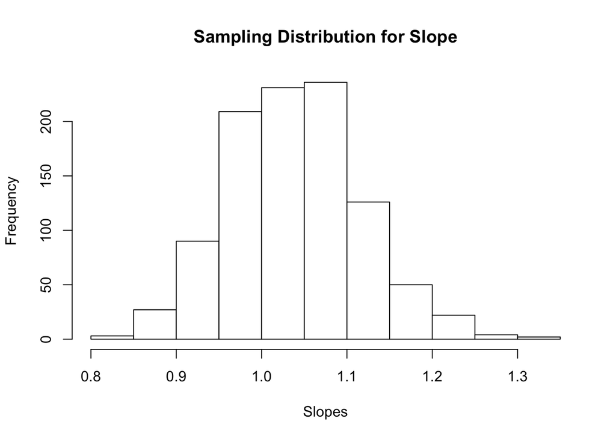

```r
# Plot 2 histograms of the sample distributions for slope and intercept
slope_plot <-hist(slopes, col = "white", main = "Sampling Distribution for Slope",
    xlab = "Slopes", ylab = "Frequency")
```

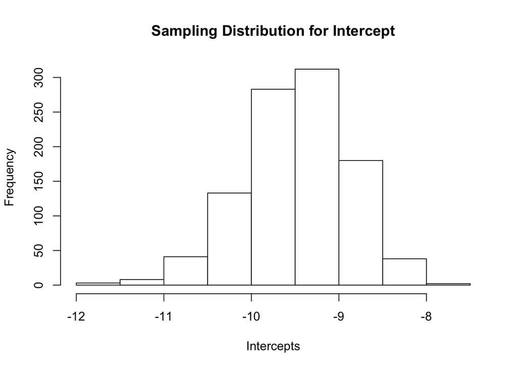

```r
int_plot <-hist(ints, col = "white", main = "Sampling Distribution for Intercept",
    xlab = "Intercepts", ylab = "Frequency")
```

[3] Estimate the standard error for each of your beta coefficients as the standard deviation of the sampling distribution from your bootstrap.

```r
# Calculate standard deviation of the sampling distribution for slope and intercept
intsd <- sd(ints)
intsd
```

```
## [1] 0.6052517
```

```r
slopesd <-sd(slopes)
slopesd
```

```
## [1] 0.07793144
```

[4] Also determine the 95% CI for each of your beta coefficients based on the appropriate quantiles from your sampling distribution.

```r
# Calculate 95% CI for slope and intercept
# For intercept
intupper <- mean(ints) + qnorm(0.975, mean = 0, sd = 1) * intsd
intlower <- mean(ints) + qnorm(0.025, mean = 0, sd = 1) * intsd
intci <- c(intlower, intupper)
intci
```

```
## [1] -10.661766  -8.289223
```

```r
# For slope
slopeupper <- mean(slopes) + qnorm(0.975, mean = 0, sd = 1) * slopesd
slopelower <- mean(slopes) + qnorm(0.025, mean = 0, sd = 1) * slopesd
slopeci <- c(slopelower, slopeupper)
slopeci
```

```
## [1] 0.8867718 1.1922574
```

[5] How does your answer to part [3] compare to the SE estimated from your entire dataset using the formula for standard error implemented in lm()?

```r
summary(m)
```

```
##
## Call:
## lm(formula = log(HomeRange_km2) ~ log(Body_mass_female_mean),
##     data = d)
##
## Residuals:
##     Min      1Q  Median      3Q     Max
## -3.3929 -0.9433 -0.0126  1.0944  3.6826
##
## Coefficients:
##                            Estimate Std. Error t value Pr(>|t|)
## (Intercept)                -9.44123    0.67293  -14.03   <2e-16 ***
## log(Body_mass_female_mean)  1.03643    0.08488   12.21   <2e-16 ***
## ---
## Signif. codes:  0 '***' 0.001 '**' 0.01 '*' 0.05 '.' 0.1 ' ' 1
##
## Residual standard error: 1.423 on 135 degrees of freedom
##   (76 observations deleted due to missingness)
## Multiple R-squared:  0.5248, Adjusted R-squared:  0.5213
## F-statistic: 149.1 on 1 and 135 DF,  p-value: < 2.2e-16
```

[6] How does your answer to part [4] compare to the 95% CI estimated from your entire dataset?

```r
confint(m)
```

```
##                                  2.5 %    97.5 %
## (Intercept)                -10.7720889 -8.110374
## log(Body_mass_female_mean)   0.8685707  1.204292
```

**The CIs for both slope and intercept is a little bit narrower in part [4] than for the the entire dataset**

[Extra credit +2]: Write a FUNCTION that takes as its arguments a dataframe (“d”), a linear model (“m”, as a character string, e.g., logHR~logBM), a user-defined confidence interval level (“conf.level”) with default = 0.95, and a number of bootstrap replicates (“n”, with default = 1000). Your function should return a dataframe that includes: beta coefficient names; beta coefficients, standard errors, and upper and lower CI limits for the linear model based on your entire dataset; and mean beta coefficient estimates, SEs, and CI limits for those coefficients based on your bootstrap.

```r
lmbootstrap <- function (d, m, conf.level = 0.95, n = 1000, var1, var2) {
m <-lm(var1~var2, data = d) #run linear regression from teh original dataset
slopes <- NULL
ints <- NULL
for (i in 1:1000){
  dsamp <- d[sample(nrow(d), length(var1), replace = TRUE),] #lenght as the lenght of a variable including in the linear model
  m2 <-lm(var1~var2, data = dsamp) #run linear regressions
  slopes <-append(slopes,m2$coefficients[2]) #add coefficients to a list for each coefficient to generate sampling distributions
  ints <- append(ints,m2$coefficients[1])
}
outcome1 <- data.frame(m$coefficients[2], m$coefficients[1], coef(summary(m))[1, "Std. Error"], coef(summary(m))[2, "Std. Error"], confint(m)[1, "97.5 %"], confint(m)[1, "2.5 %"], confint(m)[2, "97.5 %"], confint(m)[2, "2.5 %"])
  outcome2 <- data.frame(mean(slopes), mean(ints), intsd, slopesd, intci[2], intci[1], slopeci[2], slopeci[1])
    colnames(outcome1) <- c("Slope", "Intercept", "SE intercept", "SE slope", "Upper CI (intercept)", "Lower CI (intercept)", "Upper CI (slope)","Lower CI (slope)")
    colnames(outcome2) <- c("Slope", "Intercept", "SE intercept", "SE slope", "Upper CI (intercept)", "Lower CI (intercept)", "Upper CI (slope)","Lower CI (slope)")
    outcomefinal <- rbind(outcome1, outcome2)
    rownames(outcomefinal) <- c("Dataset", "Bootstrap")
    outcomefinal
  return(outcomefinal)
}
```

```r
# Using this homework's example:
x <- lmbootstrap(d=d, m=m, var1=log(d$HomeRange_km2), var2=log(d$Body_mass_female_mean))
x
```

```
##              Slope Intercept SE intercept   SE slope Upper CI (intercept)
## Dataset   1.036432 -9.441231    0.6729346 0.08487709            -8.110374
## Bootstrap 1.036432 -9.441231    0.6052517 0.07793144            -8.289223
##           Lower CI (intercept) Upper CI (slope) Lower CI (slope)
## Dataset              -10.77209         1.204292        0.8685707
## Bootstrap            -10.66177         1.192257        0.8867718
```

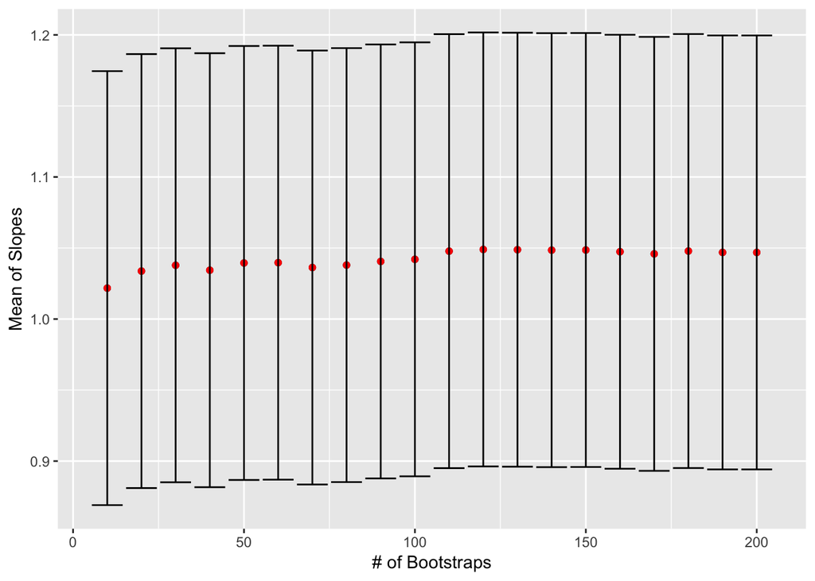

```r
# For slope
slopes <-append(slopes,m2$coefficients[2])
v <- seq(from = 10, to = 200, by = 10)
mean <- NULL
intupper <- NULL
intlower <- NULL
for(i in 1:length(v)){
    m <- mean(slopes[1:v[i]])
    mean[i] <- m
    intupper[i] <- m + qnorm(0.975, mean = 0, sd = 1) * slopesd
    intlower[i] <- m + qnorm(0.025, mean = 0, sd = 1) * slopesd
}

library(ggplot2)
data <- data.frame(mean, intupper, intlower)
g <- ggplot(data=data, aes(x = v, y = mean))
g <- g + xlab("# of Bootstraps")
g <- g + ylab("Mean of Slopes")
g <- g + geom_point()
g <- g + geom_point(aes(x = v, y = mean), colour = "red")
g <- g + geom_errorbar(aes(ymax= intupper, ymin= intlower))
g
```

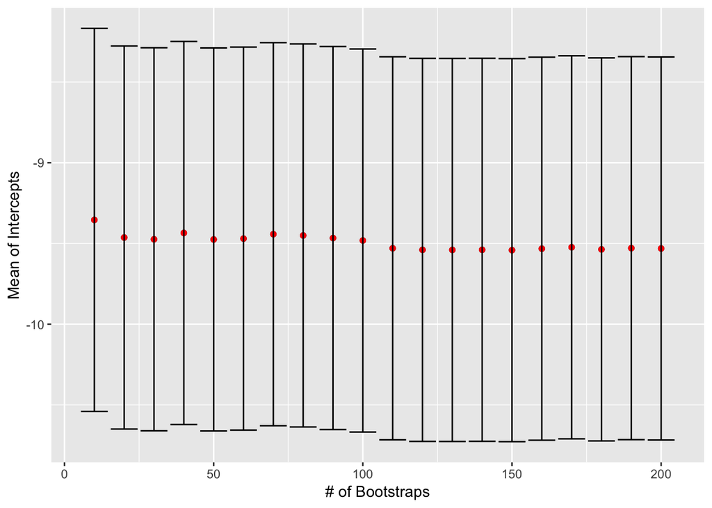

```r
# For intercept
intercepts <-append(ints,m2$coefficients[2])
v1 <- seq(from = 10, to = 200, by = 10)
mean1 <- NULL
intupper1 <- NULL
intlower1 <- NULL
for(i in 1:length(v)){
    m1 <- mean(ints[1:v[i]])
    mean1[i] <- m1
    intupper1[i] <- m1 + qnorm(0.975, mean = 0, sd = 1) * intsd
    intlower1[i] <- m1 + qnorm(0.025, mean = 0, sd = 1) * intsd
}

library(ggplot2)
data <- data.frame(mean1, intupper1, intlower1)
g <- ggplot(data=data, aes(x = v1, y = mean1))
g <- g + xlab("# of Bootstraps")
g <- g + ylab("Mean of Intercepts")
g <- g + geom_point()
g <- g + geom_point(aes(x = v1, y = mean1), colour = "red")
g <- g + geom_errorbar(aes(ymax= intupper1, ymin= intlower1))
g
```